# assignment

Marco Fiorani Borraccino

2026-04-20

```r
suppressPackageStartupMessages({
  library(epiwraps)
  library(AnnotationHub)
  library(MotifDb)
  library(memes)
  library(universalmotif)
  library(ensembldb)
  library(ggplot2)
  library(magick)
  library(motifmatchr)
  library(sechm)
  library(BSgenome.Mmusculus.UCSC.mm10)
  library(limma)
  library(betterChromVAR)
  library(rtracklayer)
  library(magick)
})
```

```
FALSE See system.file("LICENSE", package="MotifDb") for use restrictions.
```

```r
ah <- AnnotationHub(localHub=TRUE)
```

```
FALSE Using 'localHub=TRUE'
FALSE   If offline, please also see BiocManager vignette section on offline use
```

```r
ensdb <- ah[["AH89211"]] # mouse ensembldb object
```

```
FALSE loading from cache
```

## Part 1

### Download the data

```r
download.file("https://ethz-ins.org/content/w7/atac.chr19.bam", "atac.chr19.bam", mode="wb")
download.file("https://ethz-ins.org/content/w7/atac.chr19.bam.bai", "atac.chr19.bam.bai", mode="wb")
```

### Preparing tracks

```r
bam <- "atac.chr19.bam"

# create a track using all fragments, computing the coverage at each position (and force Ensembl naming)
epiwraps::bam2bw(bam, output_bw = "full_cov.bw", paired=TRUE, binWidth=10L, forceSeqlevelsStyle = "Ensembl")
```

```
## `extend` argument ignored.
```

```
## Reading in signal...
```

```
## Writing bigwig...
```

```r
# 1) create a track using only nucleosome-free fragments, the number of cuts/insertion sites at each position
bam2bw(bam, output_bw = "NF_cuts.bw", paired=TRUE, binWidth=1L, type="ends", minFragLength=30,
       maxFragLength=120, trim=4L, extend=3L, forceSeqlevelsStyle = "Ensembl")
```

```
## Reading in signal...
## Writing bigwig...
```

```r
# 2) create a track using only the (10bp) centers of mono-nucleosome fragments
bam2bw(bam, output_bw = "mono_centers.bw", paired=TRUE, binWidth=5L, minFragLength=140, trim=4L,
       maxFragLength=220, type="center", extend=10L, forceSeqlevelsStyle = "Ensembl")
```

```
## Reading in signal...
## Writing bigwig...
```

### Obtaining the sites with a TBP (TATA-binding protein) motif

```r
# get all TBP motifs
tbp_all <- MotifDb::query(MotifDb, c("TBP", "Jaspar"))
# selecting the most refined 2024 version
motif_tata <- tbp_all[["NA-jaspar2024-TBP-MA0108.3"]]
motif2 <- convert_motifs(motif_tata, class="TFBSTools-PFMatrix")
```

```
## Note: motif [motif] has an empty nsites slot, using 100.
```

```r
genome <- ah[["AH68356"]]
```

```
## loading from cache
```

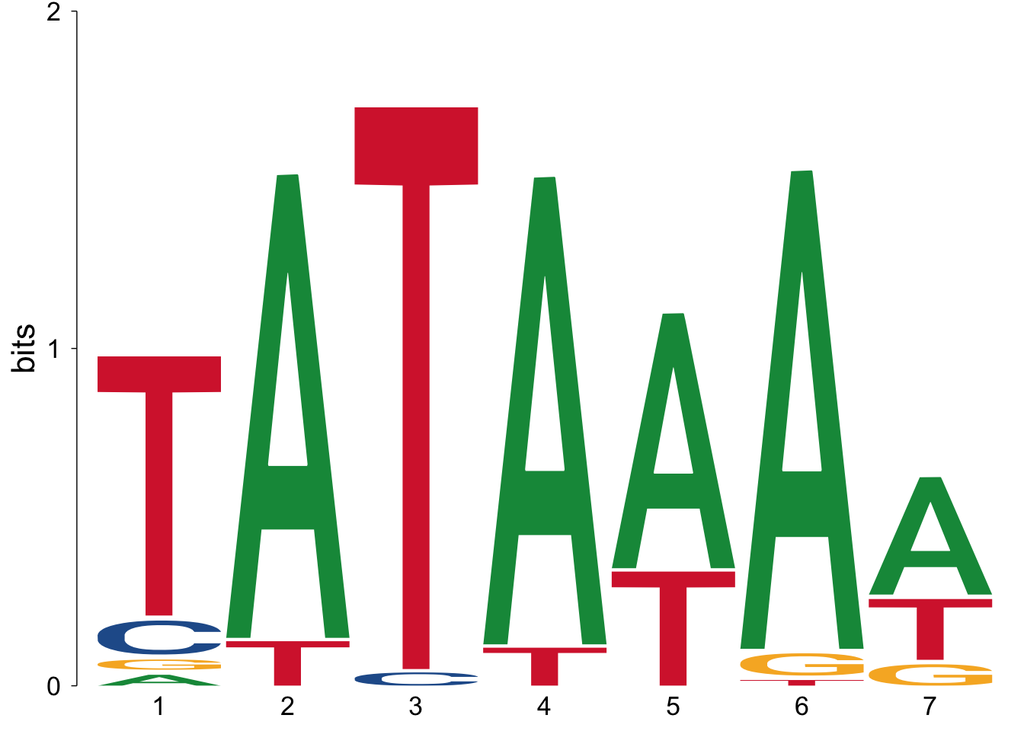

```r
# get the sequence for chr19:
chr19 <- import(genome)["19"]

# find motif matches across chr19
moi <- motifmatchr::matchMotifs(motif2, chr19, out="positions", p.cutoff=1e-5)[[1]]
# convert to GRanges
moi <- as(setNames(moi,names(chr19)), "GRanges")

view_motifs(motif_tata)
```

### Plotting signal around the motif occurences (all genome)

```r
# we prepare the list of tracks
tracks <- c("mono_centers.bw", "NF_cuts.bw", "full_cov.bw")
names(tracks) <- gsub("\\.bw", "", tracks)

# extract signals around the motif occurences
# we zoom in to 500bp around the motif centers, in windows of 5bp
sm <- signal2Matrix(tracks, moi, w=5, extend=500)
```

```
## Reading mono_centers.bw
```

```
## Reading NF_cuts.bw
```

```
## Reading full_cov.bw
```

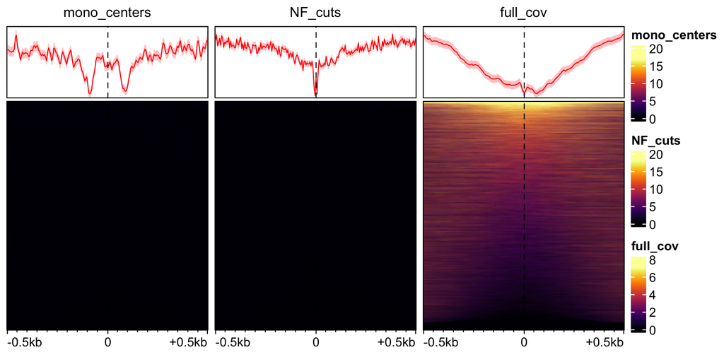

```r
# plot the signals:
plotEnrichedHeatmaps(sm, trim=0.95, multiScale = TRUE, axis_name = "0")
```

### Plotting signal around the motif occurences (filtered by open regions)

```r
# define a 500bp window around each motif center (250bp on each side)
moi_window <- resize(moi, width = 500, fix = "center")

# extract the coverage (made by 10bp bin) in these specific windows
cov_data <- import("full_cov.bw", as = "NumericList", which = moi_window)

# sum the signal for each region and assign as the score of that region
moi$score <- sapply(cov_data, sum, na.rm = TRUE)

# find the value that represents the 80th percentile
threshold <- quantile(moi$score, 0.80)

# keep only motifs with a score higher than that threshold (20% most open region -> should corresponds to active promoters/genes)
moi_active <- moi[moi$score > threshold]

# plotting with the motifs on most 20% "active promoters"
sm_filtered <- signal2Matrix(tracks, moi_active, w=5, extend=500)
```

```
## Reading mono_centers.bw
```

```
## Reading NF_cuts.bw
```

```
## Reading full_cov.bw
```

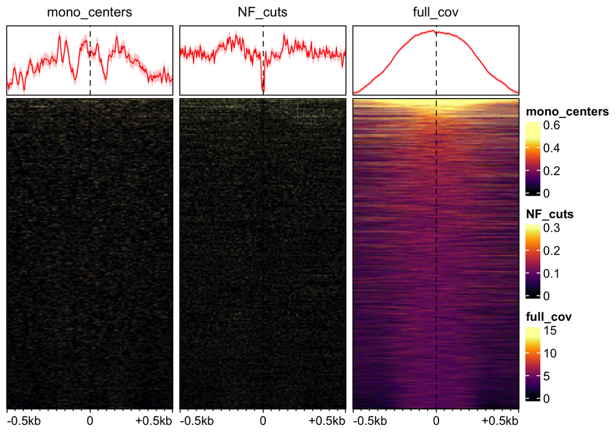

```r
plotEnrichedHeatmaps(sm_filtered, trim=0.95, multiScale = TRUE, axis_name = "0")
```

## Summarizing the signals

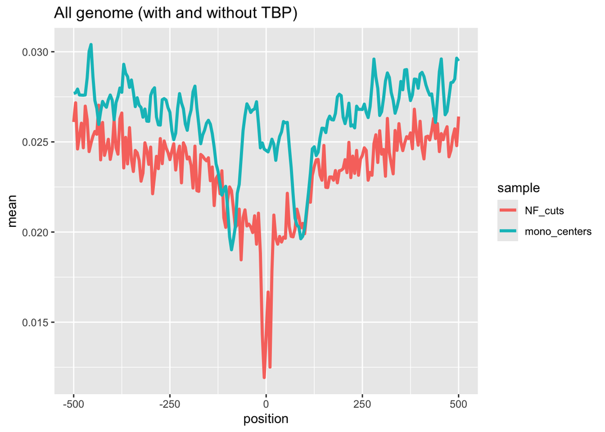

```r
# To better visualize the relationship between signals, we can overlay them aggregated across regions:
d <- meltSignals(sm[,c("NF_cuts", "mono_centers")])
ggplot(d, aes(position, mean, colour=sample)) + geom_line(size=1.2) + ggtitle("All genome (with and without TBP)")
```

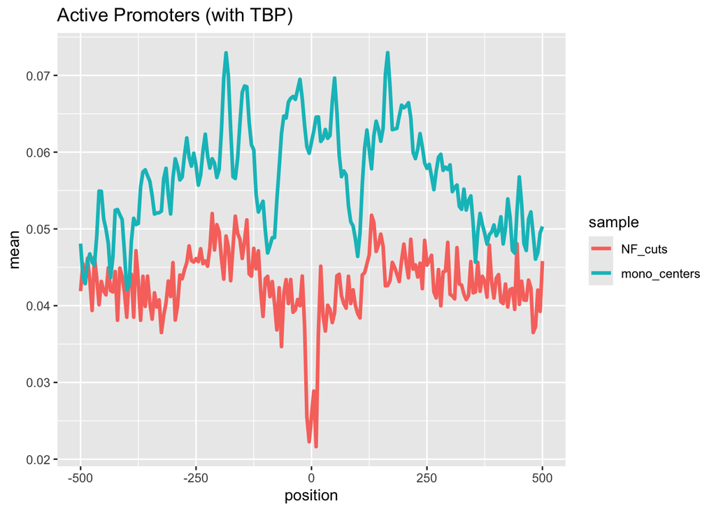

```r
d <- meltSignals(sm_filtered[,c("NF_cuts", "mono_centers")])
ggplot(d, aes(position, mean, colour=sample)) + geom_line(size=1.2) + ggtitle("Active Promoters (with TBP)")
```

```r
knitr::include_graphics("Pre-initiation-complex_TBP.png")
```

[figure not shown]

## Biological interpretation of part 1 plots

#### I’ve filtered by considering only motifs on open regions because most motif matches in the genome are actually inactive and not bound by TBP. This is because TBP is an initiatior factor of transcription and thus binds mainly the active promoters, upstream the TSS.

#### Without filtering (the first plot “all genome”) I’m averaging thousands of closed, inactive DNA regions together. This creates massive “noise” (like seeing a nucleosome sitting right over the motif) that completely hides the real biology when there is the TF.

#### With filtering: since I don’t have RNAseq of the same sample to see which promoter is actually active and thus probably bound by TBP. As a consequence, I use the simplification to consider a promoter (since the TBP motif is the core of most genes promoter) with open chromatin as an active promoter. Doing so, I’ll aim to isolate the true, active binding sites where the factor has actually attached and established a clean biological footprint.

#### The deep dip at position 0 in the “NF_cuts” signal indicates that TBP is actively bound, protecting the DNA from cleavage. In the “mono_centers” track, the two lateral peaks represent the tightly positioned nucleosomes flanking this open chromatin region. Curiously, the central peak at 0 in “mono_centers” is likely not a nucleosome; rather, it represents the massive Pre-Initiation Complex (PIC) itself. Its big size creates steric hindrance that mimics a nucleosome’s footprint by preventing Tn5 access.

#### Sometimes a figure is more explicative than words so I attached my png image of the biology that I think there is behind the shape of the last plot.

## Part 2

### Identify motifs that change in accessibility between males and females, and plot a heatmap of the deviations for the top few candidates motifs

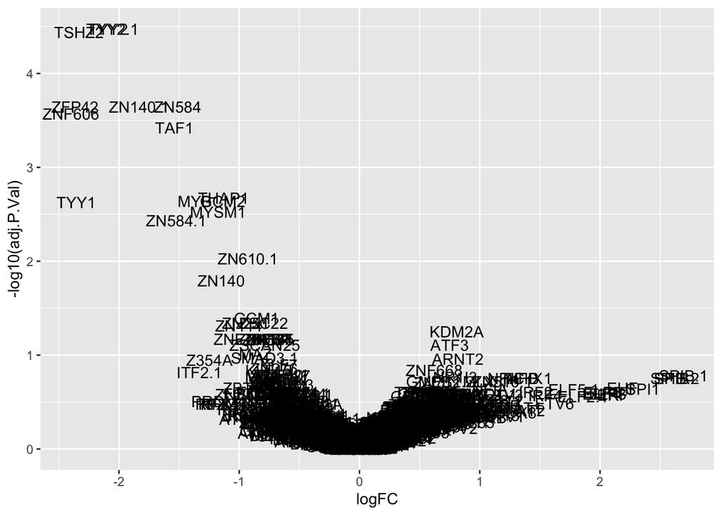

```r
# download and read data
download.file("https://ethz-ins.org/content/mouse_mm38_hippocampus.peakCounts.SE.rds", "peakCounts.rds", mode="wb")
se <- readRDS("peakCounts.rds")

# we restrict the regions to standard chromosomes and change the seq level style to match the genome
se <- GenomeInfoDb::keepStandardChromosomes(se, pruning.mode = "coarse")
seqlevelsStyle(se) <- "UCSC"
se <- addGCBias(se, genome=BSgenome.Mmusculus.UCSC.mm10)

# get a list of motifs, and then scan the regions for matches to them.
motifs <- query(MotifDb, "HOCOMOCOv13")
motifs <- do.call(TFBSTools::PWMatrixList, convert_motifs(motifs, class="TFBSTools-PWMatrix"))
names(motifs) <- make.unique(sapply(motifs, function(x) gsub("\\..+","",x@name)))

# match motifs to regions
matches <- motifmatchr::matchMotifs(motifs, se, genome=BSgenome.Mmusculus.UCSC.mm10)

# calculate deviations
dev <- betterChromVAR(se, matches)

# defefine metadata columns
dev$group <- ifelse(grepl("FSS", colnames(dev)), "Stressed", "Control")
dev$sex <- ifelse(grepl("female", colnames(dev)), "Female", "Male")

# Accounting for both variables
design_sex <- model.matrix(~ group + sex, data=as.data.frame(colData(dev)))

# differential analysis
fit_sex <- eBayes(lmFit(assay(dev, "z"), design_sex))

# extract results for sex (male vs female)
res_sex <- as.data.frame(topTable(fit_sex, coef="sexMale", number = Inf))
res_sex$motif <- row.names(res_sex)

# Volcano Plot
ggplot(res_sex, aes(logFC, -log10(adj.P.Val), label=motif)) + geom_text()
```

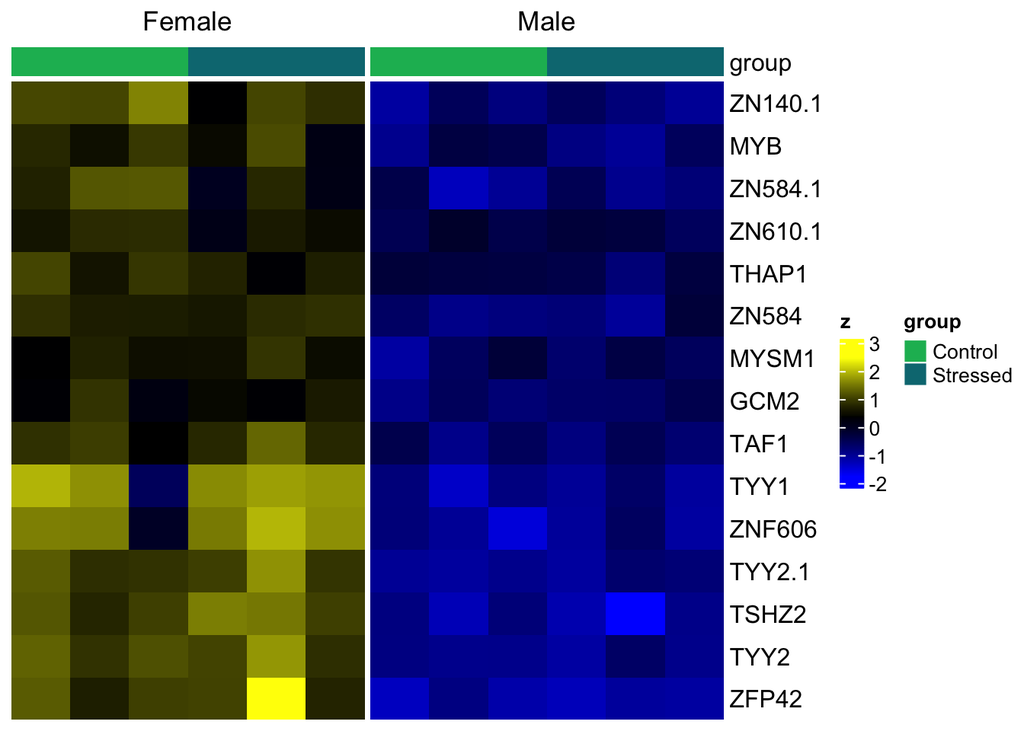

```r
# Heatmap of top 15 candidates
sechm(dev, head(row.names(res_sex), 15), gaps_at="sex", assayName = "z")
```

#### The identified motifs are transcription factor binding sites-primarily from the Zinc Finger (ZNF) and YY (Yin Yang) families that exhibit significant sexual dimorphism in chromatin accessibility. While the heatmap shows a stark contrast between males and females, the z-scores remain virtually identical between the Control and Stressed subgroups within each sex, confirming that these accessibility differences are an innate feature of sexual dimorphism in the hippocampus and not caused by the Forced Swim Stress (FSS) test. By isolating the “sexMale” coefficient in the differential analysis, the volcano plot successfully identifies these motifs as baseline markers of sex-specific chromatin organization that remain stable regardless of stress exposure.